# Bayesian Evidence Synthesis

06-12-2021

## Replication

Many scholars have advocated for the importance of replication.

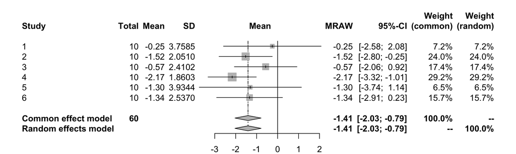

Direct replication is nice, but not enough.

## Conceptual replications

- If a study is methodologically flawed, all direct replications will inherently exploit the flaws.
- Conceptual replications try to address a single problem from different angles.
  - Different methodologies
  - Different operationalizations
- But how should we combine multiple studies with varying designs?

## Bayesian Evidence Synthesis

Instead of pooling parameter estimates, Bayesian Evidence Synthesis expresses the support for a given hypothesis in terms of a Bayes Factor (Kuiper, Buskens, Raub, & Hoijtink, 2013).

1. Construct study-specific hypotheses that reflect the models and operationalizations at hand.
2. Express the support for the study specific hypotheses in terms of a Bayes Factor.
3. Translate the Bayes Factor into posterior model probabilities.
4. Use the posterior model probabilities as prior model probabilities for the next study, and continue updating until all studies are addressed.

## Research question

A theoretical justification for the use of BES has been outlined (Kuiper, Buskens, Raub, & Hoijtink, 2013).

However, does the method work in practice as well?

How does BES behave if we combine data from three different studies (OLS regression, probit regression and logistic regression)?

To what extent do power issues affect BES?

## Simulation

Conditions:

We tested support for a single (true) hypothesis of interest versus an unconstrained hypothesis:

- \(H_1: \beta_1 < \beta_2 < \beta_3 < \beta_4; ~~~~~ H_u: \beta_1, \beta_2, \beta_3, \beta_4\)

This hypothesis was evaluated in three different studies.

- Continuous outcome, OLS regression.
- Binary outcome, probit regression.
- Binary outcome, logistic regression.
- Varying sample sizes (\(n \in \{25, 50, 100, 200, 400, 800\}\)) and effect sizes (\(R^2 \in \{0.02, 0.09, 0.25\}\)).

## Results

[figure not shown]

## Questions / comments / tips?

## References

Kuiper, R. M., Buskens, V., Raub, W., & Hoijtink, H. (2013). Combining statistical evidence from several studies: A method using bayesian updating and an example from research on trust problems in social and economic exchange. *Sociological Methods & Research*, *42*(1), 60–81. https://doi.org/10.1177/0049124112464867